# Weather Data in RDU

Jenny Xiao

10/13/2019

## Info

### Import a Json file into R

I use jsonlite package. Rjson, Rjsonio can also do it. Jasonlite package give control over vector silplification.And for numeric digit,  
RJSONIO uses significant digits, whereas jsonlite uses decimal digits. rjson does not support this.So i like to use the jsonlite package. In this project, I shall experiment weather data in the RDU area.  
[Here you can get a link](https://catalog.data.gov/dataset/local-weather-archive) for downloading JSON format of this data.

### Introduce the Weather data set

The data is the RDU weather data from 1/1/2007 to 10/8/2019. There are 4664 obs and 28 columns.  
I select the categorical variables( thunder,rain,snow,ice,fog,highwind) and quantitative  
variables(temperaturemin,temperturemax,avgwindspeed,fasteat2minwindspeed,fastest5secwinspeed,fastest2minwinddir,fastest5secwinddir).  
The fastest2minwinddir,fastest5secwinddir is 0-360, I will categorize one of it into north,east,south,west.

## Data Loading and Subset Selection

```r
library("jsonlite")
library(dplyr)
library(kableExtra)
library(tidyverse)
```

Now, we download the weather data from the above website. It can be observed that the data contains categorical variables such as fogground (YES or No) and dust (YES or NO) and numerical variables such as temperaturemin.

```r
library("jsonlite")
library(dplyr)
library(kableExtra)
library(tidyverse)

data_URL <-"https://data.townofcary.org/api/v2/catalog/datasets/rdu-weather-history/exports/json"
weatherData <- fromJSON(data_URL)
head(weatherData)
```

[output not shown]

## Data analysis

### Creating A New Variable

In what follows, I want to study a subset of the variables and add a new Variable winddir. The following code choose a few variables that I am interested for the following analysis. I convert a numerical variable called winddir to a categorical variable. Note that winddir in the original data is a numerical value that ranges from 0 to 360 degrees. Specifically, I want to convert it to four directions: east, west, north and south.

```r
weatherData <- weatherData %>% select(date,thunder,rain,snow,ice,fog,highwind,temperaturemin,temperaturemax,avgwindspeed,fastest2minwindspeed,fastest5secwindspeed,fastest2minwinddir,fastest5secwinddir) %>% mutate(winddir= ceiling(weatherData$fastest2minwinddir/90)) %>% drop_na(winddir)
weatherData$winddir<- as.factor(weatherData$winddir)

levels(weatherData$winddir)=c("North","East","South","West")
head(weatherData)
```

|  | date | thunder | rain | snow | ice | fog | highwind | temperaturemin | temperaturemax | avgwindspeed | fastest2minwindspeed | fastest5secwindspeed | fastest2minwinddir | fastest5secwinddir | winddir |
| --- | --- | --- | --- | --- | --- | --- | --- | --- | --- | --- | --- | --- | --- | --- | --- |
| 1 | 2007-01-06 | No | Yes | No | No | Yes | No | 50.0 | 71.1 | 8.05 | 17.90 | 21.92 | 230 | 230 | South |
| 2 | 2007-01-09 | No | Yes | No | No | No | No | 30.0 | 55.0 | 7.61 | 23.04 | 29.08 | 280 | 270 | West |
| 3 | 2007-01-14 | No | No | No | No | No | No | 50.0 | 73.9 | 8.50 | 21.03 | 25.05 | 230 | 230 | South |
| 4 | 2007-01-15 | No | No | No | No | No | No | 57.0 | 73.9 | 13.20 | 23.94 | 29.08 | 230 | 230 | South |
| 5 | 2007-01-20 | No | No | No | No | No | No | 26.1 | 48.0 | 4.92 | 16.11 | 21.03 | 290 | 320 | West |
| 6 | 2007-01-22 | No | Yes | No | No | Yes | No | 33.1 | 41.0 | 2.01 | 8.05 | 12.08 | 230 | 10 | South |

### Categorical summeries and Granph analysis on Thunder, Rain, Snow, Ice and Fog

```r
tabthunder<-table(as.factor(weatherData$thunder))
tabrain <- table(as.factor(weatherData$rain))
tabsnow <- table(as.factor(weatherData$snow))
tabice <- table(as.factor(weatherData$ice))
tabfog <- table(as.factor(weatherData$fog))
tabhighwind <- table(as.factor(weatherData$highwind))
tab1 <- cbind(tabthunder,tabrain,tabsnow,tabice,tabfog,tabhighwind)

kable(tab1, "html",caption = "Weather information", col.names = c("Thunder","Rain","Snow","Ice","Fog","Highwind")) %>%
 kable_styling(bootstrap_options = c("hover"))
```

Weather information

|  | Thunder | Rain | Snow | Ice | Fog | Highwind |
| --- | --- | --- | --- | --- | --- | --- |
| No | 4092 | 3791 | 4617 | 4616 | 2580 | 4660 |
| Yes | 572 | 873 | 47 | 48 | 2084 | 4 |

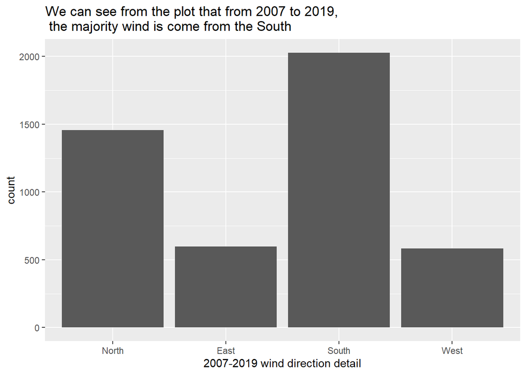

```r
ggplot(weatherData, aes(x = winddir))+ geom_bar() +
  labs(x = "2007-2019 wind direction detail",title = "We can see from the plot that from 2007 to 2019,\n the majority wind is come from the South")
```

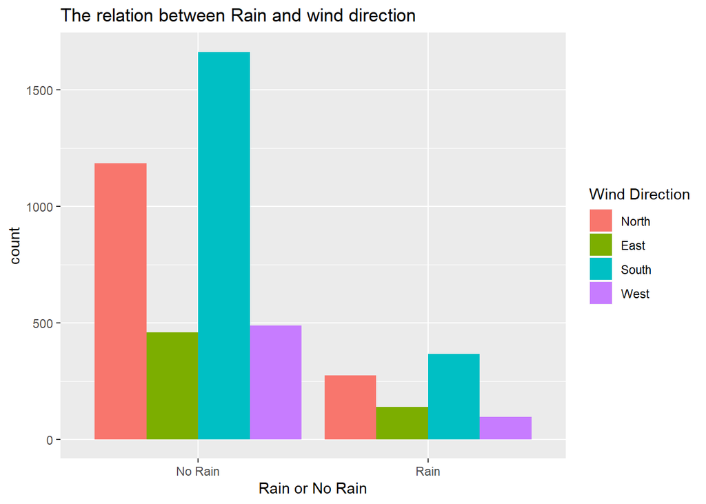

```r
ggplot(weatherData, aes(x = rain)) + geom_bar(aes(fill=winddir),position = "dodge") +
    labs(x = "Rain or No Rain",title = "The relation between Rain and wind direction") +
    scale_x_discrete(labels = c("No Rain", "Rain")) +
    scale_fill_discrete(name = "Wind Direction")
```

### Numeric Summaries by winddir

The following four tables show the day average windspeed, fastest2minspeed and fastest5secspeed  
of wind direction in terms of 6 different criteria:

```r
get_numericSummary<-function(x, ...){
  return(list(round(min(x, na.rm = TRUE),digits=1),
              round(quantile(x,0.25, na.rm=TRUE,names = FALSE),digits = 1),
              round(quantile(x,0.5,na.rm=TRUE,names = FALSE),digits = 1),
              round(mean(x, na.rm = TRUE), digits=1),
              round(quantile(x,0.75,na.rm=TRUE,names = FALSE), digits = 1),
              round(max(x, digits=1,na.rm = TRUE),digits = 1)))

}

weatherDataSouth <- weatherData[weatherData$winddir == "South",]
a <-get_numericSummary(weatherDataSouth$fastest2minwindspeed)
b <-get_numericSummary(weatherDataSouth$fastest5secwindspeed)
c <-get_numericSummary(weatherDataSouth$avgwindspeed)

summary_table <- cbind(a,b,c)
rownames(summary_table) <-c("Min", "1st Qu", "Median", "Mean", "3rd Qu", "Max")
colnames(summary_table) <-c("Fastest2minwindspeed","fastest5secwindspeed","avgwindspeed")
kable(summary_table, "html", caption="Summary of South wind speed") %>%
  kable_styling(bootstrap_options = c( "hover"))
```

Summary of South wind speed

|  | Fastest2minwindspeed | fastest5secwindspeed | avgwindspeed |
| --- | --- | --- | --- |
| Min | 4.9 | 6.9 | 0 |
| 1st Qu | 13 | 17 | 4.2 |
| Median | 16.1 | 21.9 | 6.3 |
| Mean | 17.5 | 23.2 | 6.6 |
| 3rd Qu | 21 | 28 | 8.5 |
| Max | 60 | 86.1 | 19 |

```r
weatherDataNorth <- weatherData[weatherData$winddir == "North",]
a <-get_numericSummary(weatherDataNorth$fastest2minwindspeed)
b <-get_numericSummary(weatherDataNorth$fastest5secwindspeed)
c <-get_numericSummary(weatherDataNorth$avgwindspeed)

summary_table <- cbind(a,b,c)
rownames(summary_table) <-c("Min", "1st Qu", "Median", "Mean", "3rd Qu", "Max")
colnames(summary_table) <-c("Fastest2minwindspeed","fastest5secwindspeed","avgwindspeed")
kable(summary_table, "html", caption="Summary of North wind speed") %>%
  kable_styling(bootstrap_options = c( "hover"))
```

Summary of North wind speed

|  | Fastest2minwindspeed | fastest5secwindspeed | avgwindspeed |
| --- | --- | --- | --- |
| Min | 6 | 8.1 | 0.2 |
| 1st Qu | 12.1 | 16.1 | 3.4 |
| Median | 14.1 | 19.9 | 4.9 |
| Mean | 14.6 | 20 | 5.4 |
| 3rd Qu | 17 | 23 | 6.9 |
| Max | 36.9 | 55 | 20.4 |

```r
weatherDataEast <- weatherData[weatherData$winddir == "East",]
a <-get_numericSummary(weatherDataEast$fastest2minwindspeed)
b <-get_numericSummary(weatherDataEast$fastest5secwindspeed)
c <-get_numericSummary(weatherDataEast$avgwindspeed)

summary_table <- cbind(a,b,c)
rownames(summary_table) <-c("Min", "1st Qu", "Median", "Mean", "3rd Qu", "Max")
colnames(summary_table) <-c("Fastest2minwindspeed","fastest5secwindspeed","avgwindspeed")
kable(summary_table, "html", caption="Summary of East wind speed") %>%
  kable_styling(bootstrap_options = c( "hover"))
```

Summary of East wind speed

|  | Fastest2minwindspeed | fastest5secwindspeed | avgwindspeed |
| --- | --- | --- | --- |
| Min | 6 | 8.1 | 0 |
| 1st Qu | 12.1 | 16.1 | 3.4 |
| Median | 14.1 | 18.1 | 4.7 |
| Mean | 14.3 | 19.8 | 5.1 |
| 3rd Qu | 16.1 | 23 | 6.5 |
| Max | 36 | 53.9 | 15.4 |

```r
weatherDataWest <- weatherData[weatherData$winddir == "West",]
a <-get_numericSummary(weatherDataWest$fastest2minwindspeed)
b <-get_numericSummary(weatherDataWest$fastest5secwindspeed)
c <-get_numericSummary(weatherDataWest$avgwindspeed)

summary_table <- cbind(a,b,c)
rownames(summary_table) <-c("Min", "1st Qu", "Median", "Mean", "3rd Qu", "Max")
colnames(summary_table) <-c("Fastest2minwindspeed","fastest5secwindspeed","avgwindspeed")
kable(summary_table, "html", caption="Summary of West wind speed") %>%
  kable_styling(bootstrap_options = c( "hover"))
```

Summary of West wind speed

|  | Fastest2minwindspeed | fastest5secwindspeed | avgwindspeed |
| --- | --- | --- | --- |
| Min | 6 | 8.9 | 0.2 |
| 1st Qu | 13 | 18.1 | 3.6 |
| Median | 15 | 23 | 4.9 |
| Mean | 15.5 | 23.7 | 5.3 |
| 3rd Qu | 17.9 | 28 | 6.9 |
| Max | 32 | 57.9 | 15.4 |

### Boxplot for Comparison

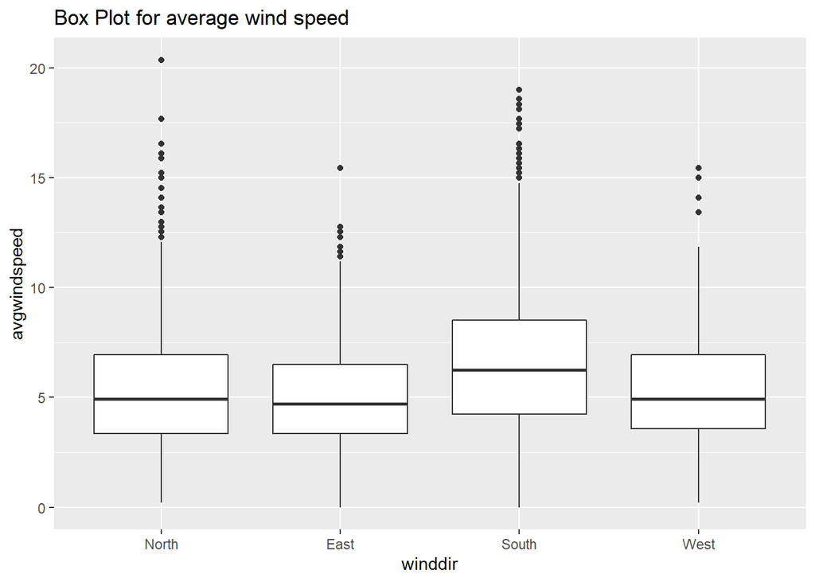

```r
g <- ggplot(weatherData, aes(x=winddir,y=avgwindspeed))

print(g + geom_boxplot() +  ggtitle("Box Plot for average wind speed"))
```

### Scatterplot for Comparison

Here we use scatterplot and smooth lines to show the correlation and regression betwween the tempreture and wind speed.

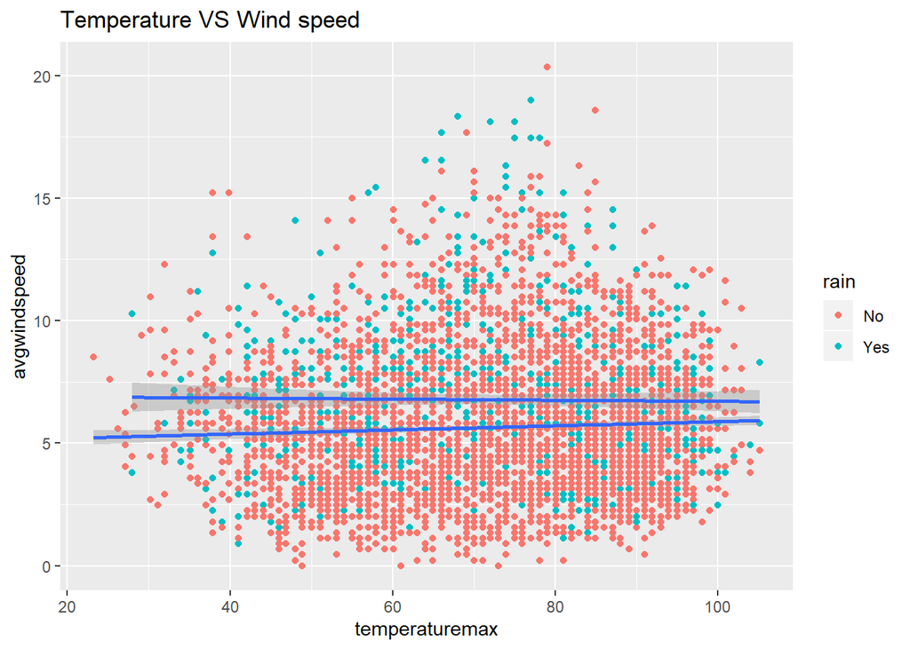

```r
g <- ggplot(weatherData, aes(x = temperaturemax, y = avgwindspeed))+
  geom_point(aes(col=rain)) +  geom_smooth(aes(group = rain), method= lm)
print(g + ggtitle("Temperature VS Wind speed "))
```